# The Many Uses of pdxTrees

`pdxTrees` is a data package composed of information on inventoried trees in Portland, OR. There are two datasets that can be accessed with this package:

- `get_pdxTrees_parks()` pulls in data on up to 25,534 trees from 174 Portland parks.
- `get_pdxTrees_streets()` pulls in data on up to 218,602 trees located on Portland’s streets. A street tree is loosely defined as a tree generally in the public right-of-way, usually between the sidewalk and the street.

The street trees are categorized by one of the 96 Portland neighborhoods and the park trees are categorized by the public parks in which they grow.

Here are some examples of the different ways `pdxTrees` can be used in an educational setting!

```r
# First make sure you have the package downloaded!

# devtools::install_github("mcconvil/pdxTrees")

# Loading the required libraries

install.packages("pdxTrees")
```

```r
library(pdxTrees)
library(ggplot2)
library(dplyr)
library(forcats)
```

First we have to grab the data. To do this we use the `get_pdxTrees_parks()` and `get_pdxTrees_streets()` functions. In this vignette, we only explore the parks dataset.

```r
# Leaving the argument field blank pulls data for all of the parks!

pdxTrees_parks <- get_pdxTrees_parks()
```

## Graphing with `ggplot2`

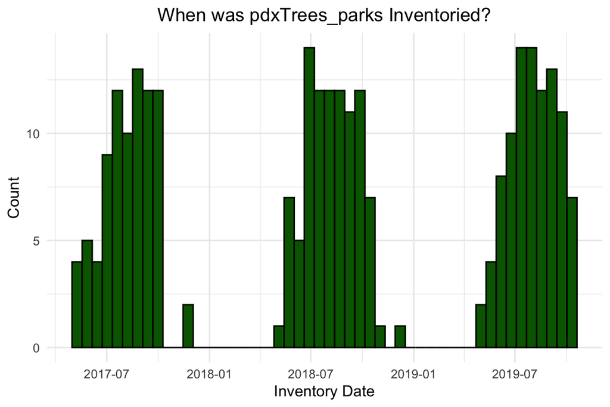

```r
# A histogram of the inventory date
pdxTrees_parks %>%
  count(Inventory_Date) %>%
  # Setting the aesthetics
  ggplot(aes(x = Inventory_Date)) +
  # Specifying a histogram and picking color!
  geom_histogram(bins = 50,
                 fill = "darkgreen",
                 color = "black") +
  labs( x = "Inventory Date",
        y = "Count",
        title= "When was pdxTrees_parks Inventoried?") +
  # Adding a theme
  theme_minimal() +
  theme(plot.title = element_text(hjust = 0.5))
```

Using `ggplot2` we can create a histogram of the `pdxTrees_parks` inventory dates. The trees were inventoried from 2017 to 2019 with the majority of the trees inventoried in the summer months, when the weather is nice in Portland.

This graph is just one of example of how `pdxTrees` can be used to create data visualizations. With a healthy mix of categorical and quantitative variables in both datasets, you can make scatterplots, bar graphs, density plots, etc. For more advanced visualizations, you can add animation with `gganimate` or create an interactive map with `leaflet`.

## An interactive map with `leaflet`

The following code creates an interactive map with `leaflet` and the `pdxTrees_parks` data. It showcases:

- Adding popups for each tree where you can customize the displayed information.
- Changing the background map.
- Including a mini-map.

```r
# Loading the leaflet packages
library(leaflet)
library(leaflet.extras)
```

```r
# Making the leaf popup icon
greenLeaflittle <- makeIcon(
  iconUrl = "https://leafletjs.com/examples/custom-icons/leaf-green.png",
  iconWidth = 10, iconHeight = 20,
  iconAnchorX = 10, iconAnchorY = 10,
  shadowUrl = "https://leafletjs.com/examples/custom-icons/leaf-shadow.png",
 shadowWidth = 10, shadowHeight = 15,
 shadowAnchorX = 5, shadowAnchorY = 5
)


# Pulling the data for Berkely Park

berkeley_prk <- get_pdxTrees_parks(park = "Berkeley Park")


# Creating the popup label

labels <- paste("</b>", "Common Name:",
                 berkeley_prk$Common_Name,
                 "</b></br>", "Factoid: ",
              berkeley_prk$Species_Factoid)


# Creating the map

leaflet() %>%
  # Setting the lng and lat to be in the general area of Berekely Park
 setView(lng = -122.6239, lat = 45.4726, zoom = 17) %>%
  # Setting the background tiles
  addProviderTiles(providers$Esri.WorldTopoMap) %>%
  # Adding the leaf markers with the popup data on top of the circles markers
  addMarkers( ~Longitude, ~Latitude,
              data = berkeley_prk,
             icon = greenLeaflittle,
              popup = ~labels) %>%
  # Adding the mini map at the bottom right corner
  addMiniMap()
```

[interactive chart not shown]

## Creating an animated graph using `gganimate`

```r
library(gganimate)
```

Before you animate a graph with `gganimate` you have to create and save a graph with `ggplot2`.

```r
# Refactoring the categorical mature_size variable
berkeley_prk <- berkeley_prk %>%
 mutate(mature_size = fct_relevel(Mature_Size, "S", "M", "L"))


# First creating the graph using ggplot and saving it!
berkeley_graph <- berkeley_prk %>%
  # Piping in the data
                  ggplot(aes(x = Tree_Height,
                              y = Pollution_Removal_value,
                              color = Mature_Size)) +
  # Creating the scatterplot
                  geom_point(size = 2, alpha = 0.5) +
                  theme_minimal() +
  # Adding the labels
                  labs(title = "Pollution Removal Value of
                       Berkeley Park Trees",
                       x = "Tree Height",
                       y = "Pollution Removal Value ($'s annually)",
                       color = "Mature Size") +
  # Adding a color palette
                  scale_color_brewer(type = "seq", palette = "Set1") +
  # Customizing the title font
                  theme(plot.title = element_text(hjust = 0.5,
                                                  size = 8,
                                                  face = "bold"),
                         axis.title.x = element_text(size = 6),
                         axis.text = element_text(size = 4),
                         axis.title.y = element_text(size = 6),
                        legend.title = element_text(size = 6),
                        legend.text = element_text(size= 4))
```

Now we can add animation!

```r
# Then adding the animation with gganimate functions

 berkeley_graph +
  # Choosing which variable we want to annimate
  transition_states(states = Mature_Size,
                    # How long each point stays before fading away
                    transition_length = 10,
                    # Time the transition takes
                    state_length = 8)  +
  # Animation for the points entering
  enter_grow() +
  # Animation for the points exiting
  exit_shrink()
```

[output not shown]

Unsurprisingly it seems that large trees have the highest degree of pollution removal. However, there is a lot of overlap between the categories that could likely be explained by other key variables, like `Species`. This is a great opportunity to practice multivariate thinking!

## A Linear Regression

Aside from visualizations, the data can also be used to build linear regression models, create confidence intervals, and perform many other forms of statistical inference.

Let’s look at the relationship between `Tree_Height` and `Pollution_Removal_value`.

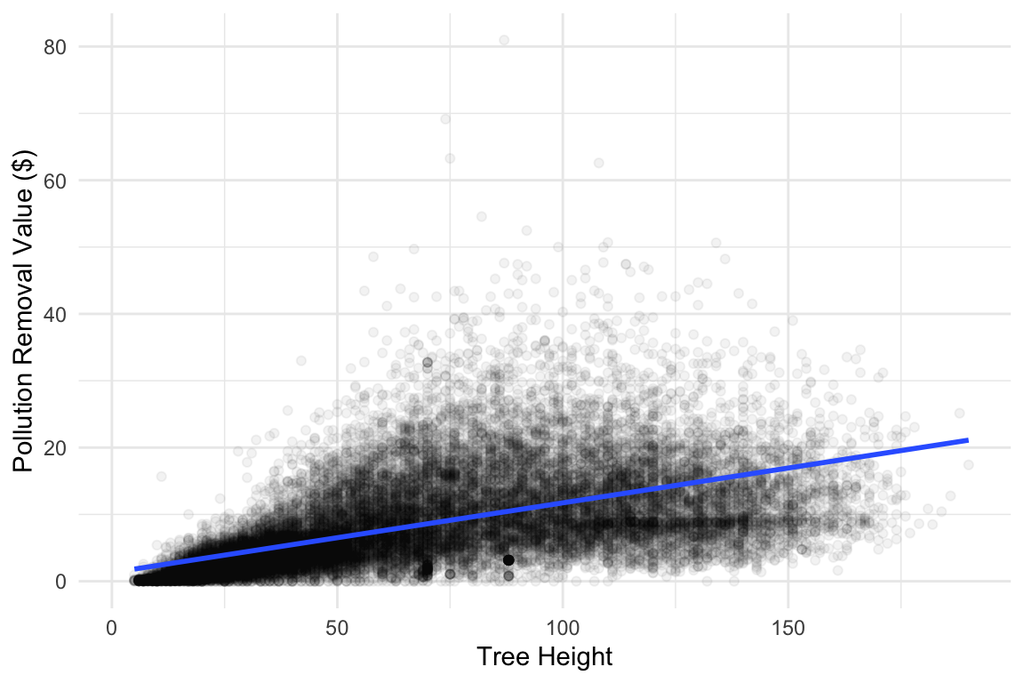

```r
# Visualizing the relationship between the two variables.
ggplot(pdxTrees_parks, aes(x = Tree_Height,
                           y = Pollution_Removal_value)) +
 # Creating a scatter plot
  geom_point(alpha = 0.05) +
 # Adding the line of best fit
  stat_smooth(method = lm, se = FALSE) +
  theme_minimal() +
  labs(x = "Tree Height",
       y = "Pollution Removal Value ($)")
```

```r
# moderndive is where the get_regression_table() function lives
library(moderndive)

# Running a linear regression of Pollution_Removal_value on Tree_Height
mod <- lm(Pollution_Removal_value ~ Tree_Height, data = pdxTrees_parks)

# Printing the coefficients table
get_regression_table(mod)
```

```
#> # A tibble: 2 × 7
#>   term        estimate std_error statistic p_value lower_ci upper_ci
#>   <chr>          <dbl>     <dbl>     <dbl>   <dbl>    <dbl>    <dbl>
#> 1 intercept      1.31      0.071      18.5       0    1.17     1.44
#> 2 Tree_Height    0.104     0.001     114.        0    0.102    0.106
```

Looking at the graph and the slope coefficient from the regression table, it does seem like tree height positively correlates with pollution removal. In particular, with a $\hat\beta_1$ of $0.104$, we’d estimate that the `Pollution_Removal_value` increases by $0.104$ with each additional foot of `Tree_Height`.